# KnowHydraulicModel

Jinyan

24 August 2020

## 1.Darcy's Law

According to Darcy's Law, the amount of water (transpiration; E) goes through a tude (xylem) is
$$E = (\psi_s - \psi_p) k_p$$

$\psi_s , Soil \space water \space potential \space (MPa)$

$\psi_p , Plant \space water \space potential \space (MPa)$

$k_p , Plant \space hyraulic \space conductance \space (mmol \space MPa^{-1} \space s^{-1})$

The key question of this equation is to get $\psi_p$ and $k_p$...

### 1.1 The simple assumption

Why don't we just assume the $\psi_p$ is $\psi_{leaf}$ and $k_p$ is $k_{stem}$! Solves all the issues and can be measured.

Although earlier models even assume $k_{stem}$ to be constant, we could add the PLC curve to it

$$k_{stem} = (1-{1\over(1+e^{a (\psi_{Leaf} - b)})}) k_{sat}$$
$k_{sat}, Plant \space hyraulic \space conductance \space at \space saturate \space potential \space (mmol \space MPa^{-1} \space s^{-1})$

$a,b , the \space slope \space (unitless) \space and \space \psi_{leaf} \space \space at \space which \space conductance \space is \space reduced \space to \space 50\% \space(MPa)$

### 1.2 What can be calculated from the simple assumption

Given the measurements of PLC and Water potentials, one could estimate the transpiration rate with Darcy's Law.

Another interesting feature is that a maximum E of plant can be calculated. We know that the pressure grediant is larger when $\psi_{leaf}$ is more negative, but at the same time $k_{stem}$ is getting smaller.

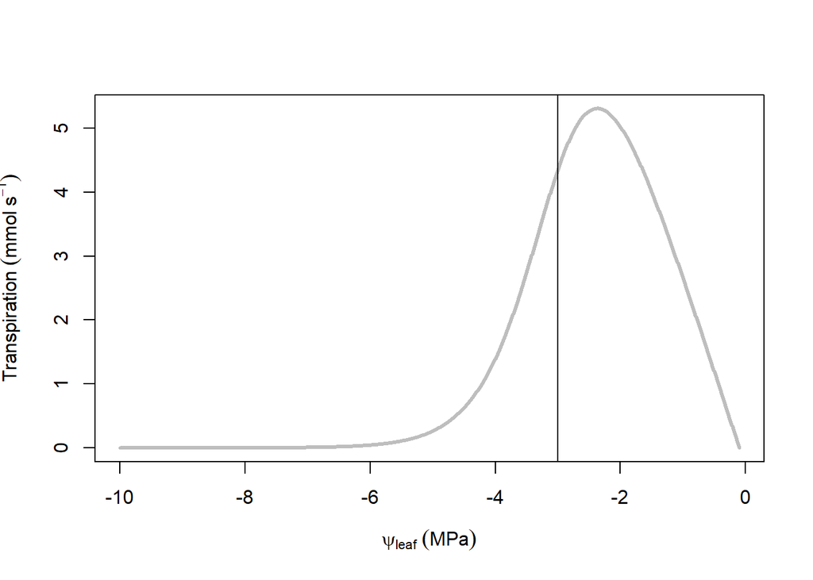

### 1.3 The more correct assumption

The above assumption is simple but clearly wrong. We know the conductances and water potentials are different in roots, along the stem, and in leave. The correct way of calculating the conductance of the whole plant is thus getting the integral over the hydraulic pathway as proposed by Sperry et al. (1998) https://onlinelibrary.wiley.com/doi/10.1046/j.1365-3040.1998.00287.x.

In the Sperry paper, there's also a new term 'critial water potential' which is the water potential that plants do not get below. Because of this critial water potential, there's the associated critial tranpiration rate.

Although the Sperry model is more correct and often the version used in the model, the simple assumption is similar enough to the Sperry model numerically. We thus will use the simple assumption for this demonstration.

## 2. Stomatal model

### 2.1 The Tuzet model

In the demo, we will use the empirical model proposed by Tuzet et al. (2003) http://doi.wiley.com/10.1046/j.1365-3040.2003.01035.x.

$$g_s = 1.6 \times g_1 \times {A \over C_a} \times f_{\psi}$$

$g_1, an \space empirical \space slope \space parameter$

$f_{\psi}, sigmoidal \space function \space based \space on \space \psi_{leaf}$

The sigmoidol function is very similar to the PLC curve. For the ease of understanding, one can assume them to be the same but keep in mind that they are not =)

The photosynthesis part is based on the Farquhar-von Caemmerer–Berry photosynthesis model (Farquhar et al. 1980) https://link.springer.com/article/10.1007/BF00386231.

### 2.2 Fitting Tuzet model to data

With an ideal gas excahnge - water potential dataset, we can thus estimate $g_1$ by fitting the model to the data. However, we need to know the $\psi_{leaf}$ as the time of $g_s$ and photosynthesis being measured, which is impossible with current tools.

In a more common set up, we will have, A, $g_s$, and $\psi_{predawn}$. We then need to make assumptions about how water get tranported from soil to leaf in the previous section.

I'll use this shiny app to demonstrate how the calculation is done. https://jinyan-yang.shinyapps.io/Tuzet_app_10/?_ga=2.36363302.767189343.1598235292-645106265.1592366832

### 2.3 Using Tuzet model to predict

Given the parameter values ($g_1$ and those for photosynthesis), one can thus estimate $g_s$ and thus transpiration with the Tuzet model.

Here are some data from EucFACE.

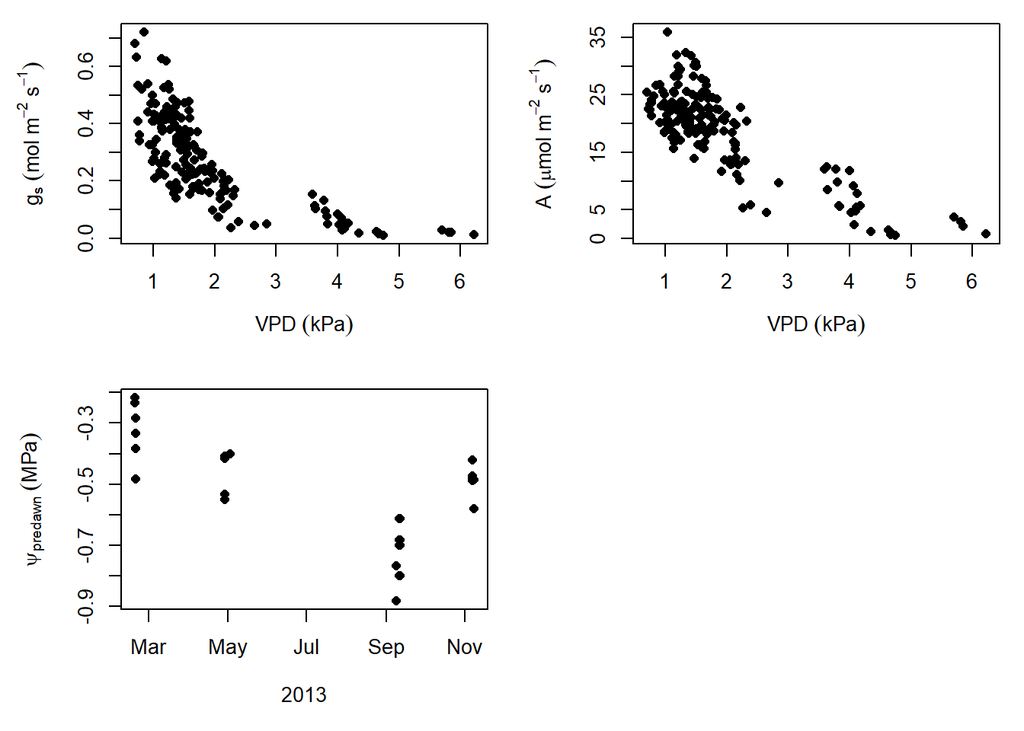

We have fitted the Tuzet model to the data and here's fit.

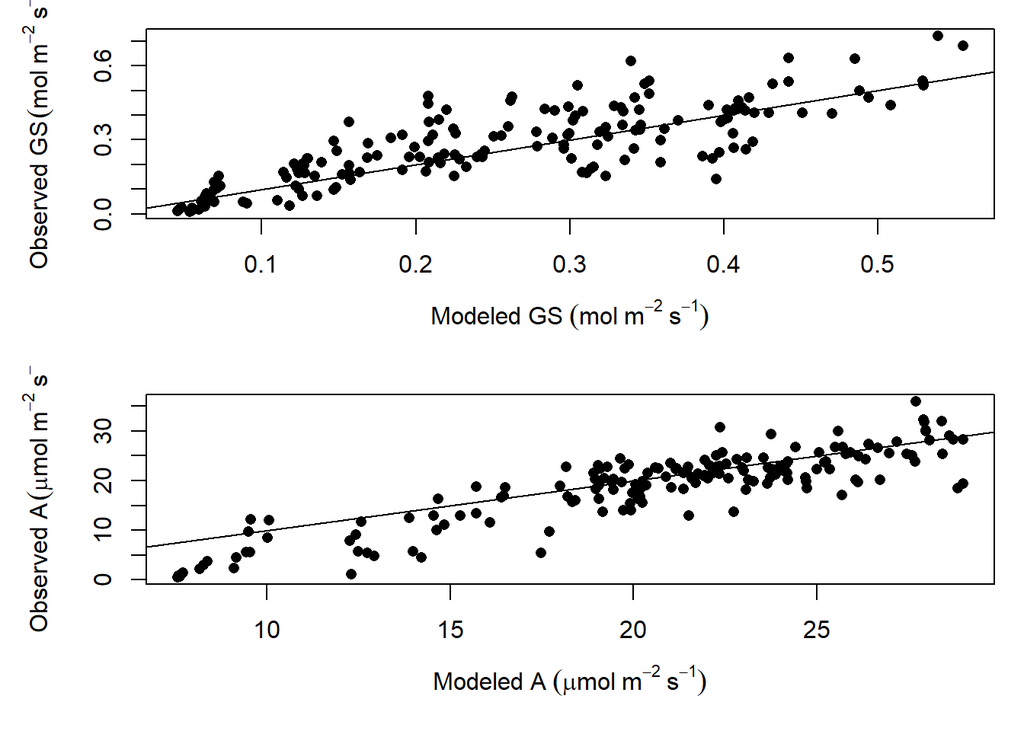

### 2.4 How to form your hypothesis

Using the abov model frame work (perhaps the shiny app also), it is possible to explore the relationship among parameters. This is useful because photosynthesis, stomatal conductance, and leaf water poetential are ineteracted.

Here, I'll start by proposing a question. Assuming two individuals of the the same species. One is in nutrient rich soil and the other nutrient limited. We may expact their leaf N to be different and thus different Vcmax/Jmax. But if we give them the same amount fo water, then they have the same $\psi_s$. If Vcmax/Jmax is lower, should $\psi_{leaf}$ increase or derease with all else being the same.

### 2.5 Issues of Tuzet model

The first issue is that the model is very difficult to fit. The reason is there are too many parameters and they relate to each other.

The second issue is worse and relates to the assumption of the model.

The model assumes plants to pass P50 to reduce transpiration under high VPD. This is not only not supported by data but also not reasonable even in theory. It is better shown with the shiny app. Since a lower tranpiration can be achieved at a less negative $\psi_{leaf}$, there's no reason for the plants to go beyond the optimal $\psi_{leaf}$. #

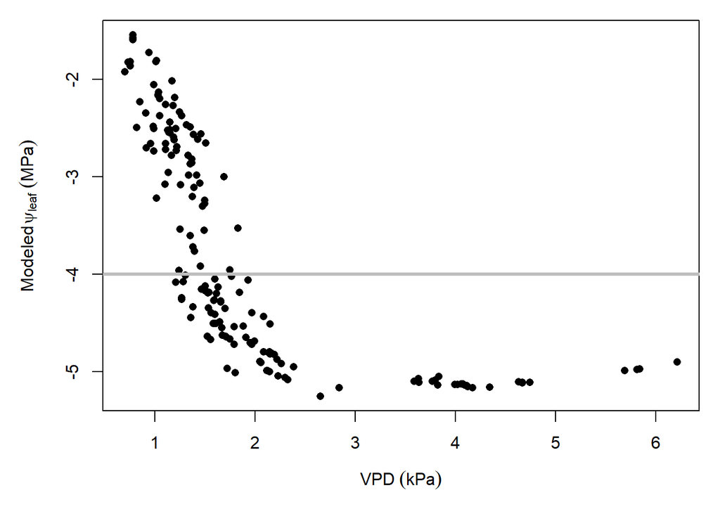

## Future topics

### Safty-gain trade-off optimisation model

There is a new optimality model developed by Sperry et al. (2017) https://onlinelibrary.wiley.com/doi/full/10.1111/pce.12852, which avoids the above issues.

This model also has PLC and hydraulic pathways as well as photosynthesis. The unique feature of this model is that it assumes plant regulate stomatal conductance model so hydraulic conductance loss is minised and phtosynthesis is maximised.

In this model, we know that plant will loss more conductance if allowing higher $g_s$. But at the same time, with high $g_s$, photosynthesis is also higher assuming all else being equal. Consequently, plants need to optimise $g_s$ to envronmental conditions so a max photosynthesis can be achieved with a min loss of hydraulic conductance. Different plants will also respond differntly due to different hydraulic traits.

### Whole-plant reponse during drought

Above is a demonstration of how $g_s$ respond to short-term environmental changes. The whole-plant response to drought is more complex. For instance, plant can shed leaves to keep $g_s$ high.